# Como realizar uma análise descritiva de dados usando Jupyter (para quem nunca usou, mas gostaria).

### por Rodrigo H. Correa

A ideia desse notebook é trazer proximidade ao usuário de ferramentas de dados um maior conforto usando ferramentas do Python, principalmente do Jupyter Notebook.

Nesse notebook farei uma análise exploratória básica, mostrando quais os principais conceitos necessários para obter informação sobre dados de forma rápida e simples.

Com o intuito de repassar informação para ser usada como um tutorial para aspirantes à análise de dados, farei o código de forma comentada e passo-a-passo.

## O que é Jupyter?

Jupyter notebook é justamente esse arquivo. Não é um arquivão de texto, na verdade é uma interface de código, o qual você pode introduzir código em Python e criar um "caderno" com o passo a passo do código, comentável e editável.

Ou seja:

##### Reprodutível!

E aí que está a importância! Você pode compartilhar sua análise e reproduzir os resultados, dando credibilidade e trazendo facilidade para todos acompanharem suas análises.

#### Matar a cobra, mostrar o pau.

## Por que estou fazendo esse notebook?

Eu comecei a fazer meu primeiro código em R em 2016. Meu background não é técnico, muito embora eu já soubesse conceitos estatísticos complexos. Não sabia uma linha de código, e confesso, tinha até mesmo um certo bloqueio.

Em 2017, resolvi fazer um curso do MIT que envolvia criar algoritmos de Machine Learning; com o pouco tempo que tinha para aprender, acabei buscando tutoriais e executando linhas na tentativa e erro.

Porém, eu nunca encontrei algo que eu realmente conseguisse aprender rapidamente sozinho, e por muito tempo foi um aprendizado vagaroso. Eu gosto de saber o "por que" das coisas.

Quando migrei para o Python, vi muitos notebooks excelentes, mas a maioria deles focava em públicos mais avançados; do tipo "oi, vamos para o que interessa". E sempre foi uma leitura difícil para buscar entender o que estava sendo repassado.

Por isso, se você está bem no começo da sua jornada de dados.... Vou tentar te ajudar!

## O que você precisa para aprender desse notebook?

Muita curiosidade!

Mas, o que estou fazendo de diferente é buscando ser mais didático, para apresentar o que pode ser feito numa análise exploratória de dados, e buscando traduzir os comandos que realizo para chegar lá.

## Quais dados estou usando?

Bom, para esta análise, resolvi utilizar um dataset que encontrei no Kaggle (www.kaggle.com) sobre as músicas da Billboard desde os anos 50 versus sua popularidade no Spotify hoje.

Onde encontrei: no site do Kaggle, há uma aba chamada Datasets. Ali você pode encontrar diversas bases de dados para poder brincar.

Como um dos meus hobbies é música, optei por esse dataset.

#### As técnicas usadas aqui, entretanto, servem para qualquer dataset que você queira usar!

## Passo número zero: Importar as bibliotecas (ou libraries)

Essa é uma boa prática de quando você estiver construindo Jupyter Notebooks.

Uma coisa boa do Jupyter é que você pode editar o código. Ou seja, se os comandos porventura forem errados, você pode corrigí-los.

Aqui, você vai "baixar" uma vasta gama de código já pré preparado e separado numa chamada biblioteca, que é capaz de processar informação com objetivos específicos.

E se, mais adiante na análise eu descobrir que preciso de outras bibliotecas? Basta voltar ao início, inserir a biblioteca e seguir adiante.

### Primeiro import e primeiro alias

A função import é que que habilita a library para ser usada durante seu trabalho; ou seja, sem fazer o import, não é possível utilizar as funções da library que queremos.

O alias é um apelido, ou seja, como vamos chamar essa library dentro do Python.

A primeira library que chamaremos é a pandas, uma das principais para tratamento de dados no Python. vamos usar o alias pd.

```python
import pandas as pd
```

### Próximos imports e aliases

Seguindo a mesma lógica, vamos importar outras libraries importantes.

Numpy - tratamento numérico. O alias será np

Matplotlib.pyplot - Gráficos. O alias será plt

Seaborn - Gráficos. O alias será sns

Seguindo a mesma fórmula da importação da library Pandas, vamos fazer as importações necessárias:

```python
import numpy as np
import matplotlib.pyplot as plt
import seaborn as sns
```

Agora que importamos as principais libraries que vamos usar, o passo número um é importar os dados que vamos utilizar.

## Passo número 1: Importar os dados!

Esse é realmente o primeiro passo que estamos tomando para realizar a análise dos dados, e é bastante importante para que possamos prosseguir que os dados sejam importados corretamente!

Uma boa prática é que você tenha um diretório de trabalho em que você guarde todos os seus arquivos que vai utilizar para análise de dados.

A função a ser utilizada para a leitura dos dados é a read_csv() que está dentro da library pandas.

Por isso, vamos utilizar o comando pd.read_csv()

É importante notar que eu criei o que é chamado objeto: o df, de dataframe.

#### Toda vez que eu fizer a chamada para df significa que estou realizando algum tipo de análise dessa base de dados.

#### Meu comando aqui é: Python, leia o arquivo .csv e crie um objeto com ele chamado df usando pandas (pd).

```python
df = pd.read_csv('Billboard-Weekly-Songs-With-Song-And-Artist-Spotify-Popularity.csv')
```

## Passo 2: cabeçalho, cauda, informação e descrição

Agora que temos a base de dados junto ao Python, vamos primeiro entender o que está se passando.

O primeiro comando é para entender o cabeçalho da base de dados; esse comando é o head.

E vou usar a minha primeira chamada ao df: df.head()

Isso significa que eu quero o cabeçalho (head) da base de dados.

#### Meu comando aqui é: Python, apresente o cabeçalho de df.

```python
df.head()
```

|  | date | Rank | Title | Artist | Weeks on chart | year | Spotify_Popularity | Artist_Popularity |
| --- | --- | --- | --- | --- | --- | --- | --- | --- |
| 0 | 1955-01-01 | 1 | Poor Little Fool | Ricky Nelson | 1.0 | 1955 | -1 | 56 |
| 1 | 1955-01-01 | 2 | Patricia | Perez Prado And His Orchestra | NaN | 1955 | -1 | 12 |
| 2 | 1955-01-01 | 3 | Splish Splash | Bobby Darin | NaN | 1955 | -1 | 62 |
| 3 | 1955-01-01 | 4 | Hard Headed Woman | Elvis Presley With The Jordanaires | NaN | 1955 | -1 | -1 |
| 4 | 1955-01-01 | 5 | When | Kalin Twins | NaN | 1955 | -1 | 24 |

#### No cabeçalho, podemos ver quando começou a observação dos dados da Billboard: 1955.

Podemos ver também quais as variáveis que temos no Dataset:

Date - Data da publicação da lista.

Rank - Posição que ocupou a lista.

Title - Título da Música.

Artist - Artista.

Weeks on chart - Semanas em que a musica consta na lista.

Year - Ano da lista.

Spotify_Popularity - popularidade no Spotify.

Artist_Popularity - popularidade do Artista no Spotify.

#### Agora, vamos verificar a cauda dos dados.

Essa análise é importante principalmente para verificamos está tudo consistente, se não há uma coluna em que as informações foram perdidas, etc.

Dessa vez, farei uma chamada com um número dentro de tail. Isso apenas para demonstrar que, assim como head(), eu posso colocar arbitriariamente um valor de observações para serem visualizadas.

##### Eu quero as 20 últimas observações, como fazer?

Basta inserir o número de observações que você quer visualizar dentro dos parênteses.

#### Meu comando: Python, apresente a cauda da base de dados df.

```python
df.tail(20)
```

|  | date | Rank | Title | Artist | Weeks on chart | year | Spotify_Popularity | Artist_Popularity |
| --- | --- | --- | --- | --- | --- | --- | --- | --- |
| 300580 | 2017-12-22 | 81 | Ghostface Killers | 21 Savage, Offset & Metro Boomin Featuring Tra... | 6.0 | 2017 | -1 | -1 |
| 300581 | 2017-12-22 | 82 | F**k Love | XXXTENTACION Featuring Trippie Redd | 15.0 | 2017 | -1 | -1 |
| 300582 | 2017-12-22 | 83 | Mayores | Becky G Featuring Bad Bunny | 7.0 | 2017 | -1 | -1 |
| 300583 | 2017-12-22 | 84 | You Broke Up With Me | Walker Hayes | 7.0 | 2017 | 64 | 64 |
| 300584 | 2017-12-22 | 85 | Krippy Kush | Farruko, Nicki Minaj, Bad Bunny, 21 Savage & R... | 2.0 | 2017 | -1 | -1 |
| 300585 | 2017-12-22 | 86 | When We | Tank | 3.0 | 2017 | 64 | 62 |
| 300586 | 2017-12-22 | 87 | Jocelyn Flores | XXXTENTACION | 15.0 | 2017 | 89 | 98 |
| 300587 | 2017-12-22 | 88 | Written In The Sand | Old Dominion | 3.0 | 2017 | 73 | 73 |
| 300588 | 2017-12-22 | 89 | Too Much To Ask | Niall Horan | 7.0 | 2017 | 76 | 77 |
| 300589 | 2017-12-22 | 90 | Broken Halos | Chris Stapleton | 5.0 | 2017 | 70 | 77 |
| 300590 | 2017-12-22 | 91 | All On Me | Devin Dawson | 3.0 | 2017 | 41 | 65 |
| 300591 | 2017-12-22 | 92 | Transportin' | Kodak Black | 16.0 | 2017 | 74 | 91 |
| 300592 | 2017-12-22 | 93 | Juice | Yo Gotti | 7.0 | 2017 | 62 | 77 |
| 300593 | 2017-12-22 | 94 | Ask Me How I Know | Garth Brooks | 7.0 | 2017 | -1 | 52 |
| 300594 | 2017-12-22 | 95 | Bella y Sensual | Romeo Santos Featuring Nicky Jam & Daddy Yankee | 3.0 | 2017 | -1 | -1 |
| 300595 | 2017-12-22 | 96 | Faking It | Calvin Harris Featuring Kehlani & Lil Yachty | 3.0 | 2017 | -1 | -1 |
| 300596 | 2017-12-22 | 97 | Marry Me | Thomas Rhett | 15.0 | 2017 | 75 | 78 |
| 300597 | 2017-12-22 | 98 | Five More Minutes | Scotty McCreery | 15.0 | 2017 | 65 | 66 |
| 300598 | 2017-12-22 | 99 | Criminal | Natti Natasha x Ozuna | 15.0 | 2017 | -1 | -1 |
| 300599 | 2017-12-22 | 100 | Sauce It Up | Lil Uzi Vert | 15.0 | 2017 | 74 | 89 |

### Usando df.head() e df.tail(), já consigo saber que estamos observando rankings Billboard entre 1955 e 2017.

### Próxima Análise: df.info()

Agora, eu quero saber quantas observações estamos trabalhando.

Qual o tamanho da nossa base de dados?

Também, qual tipo de dados estamos trabalhando? Isso é de suma importância caso eu queria, por exemplo, realizar uma soma ou uma média.

Para isso, vou usar df.info()

#### O comando é: apresente as informações de df.

```python
df.info()
```

```
<class 'pandas.core.frame.DataFrame'>
RangeIndex: 300600 entries, 0 to 300599
Data columns (total 8 columns):
 #   Column              Non-Null Count   Dtype
---  ------              --------------   -----
 0   date                300600 non-null  object
 1   Rank                300600 non-null  int64
 2   Title               300600 non-null  object
 3   Artist              300600 non-null  object
 4   Weeks on chart      280980 non-null  float64
 5   year                300600 non-null  int64
 6   Spotify_Popularity  300600 non-null  int64
 7   Artist_Popularity   300600 non-null  int64
dtypes: float64(1), int64(4), object(3)
memory usage: 18.3+ MB
```

Junto com df.info(), vamos usar o df.describe(), que darão um overview do dataset.

Ele trará:

Número de observações (count)

Média (mean)

Desvio-Padrão (std)

Mínimo (min)

Primeiro Quartil (25%)

Mediana (50%)

Terceiro Quartil (75%)

Máximo (max)

#### O comando é: descreva estatisticamente df.

```python
df.describe()
```

|  | Rank | Weeks on chart | year | Spotify_Popularity | Artist_Popularity |
| --- | --- | --- | --- | --- | --- |
| count | 300600.000000 | 280980.000000 | 300600.000000 | 300600.000000 | 300600.000000 |
| mean | 50.498307 | 9.561766 | 1986.167665 | 21.500709 | 47.864647 |
| std | 28.865287 | 7.203444 | 18.108702 | 26.542699 | 28.087668 |
| min | 1.000000 | 1.000000 | 1955.000000 | -1.000000 | -1.000000 |
| 25% | 26.000000 | 4.000000 | 1971.000000 | -1.000000 | 29.000000 |
| 50% | 50.000000 | 8.000000 | 1986.000000 | -1.000000 | 56.000000 |
| 75% | 75.000000 | 13.000000 | 2002.000000 | 46.000000 | 69.000000 |
| max | 100.000000 | 87.000000 | 2017.000000 | 90.000000 | 100.000000 |

#### Aqui temos então um conjunto de informações importantes sobre nosso dataset.

Sabemos que são 300 mil observações (count) , que a média de popularidade das músicas listadas é de 21/100 (mean Spotify_Popularity).

## Passo 3: tratar os dados!

Já vimos, primeiramente, alguns potenciais probleminhas que precisam ser endereçados para fazermos uma boa análise.

o primeiro deles é o NaN que apareceu no head da distribuição.

NaN significa not a number, e é um dos casos de dados que estão faltando numa observação.

Não viu?

```python
df.head()
```

|  | date | Rank | Title | Artist | Weeks on chart | year | Spotify_Popularity | Artist_Popularity |
| --- | --- | --- | --- | --- | --- | --- | --- | --- |
| 0 | 1955-01-01 | 1 | Poor Little Fool | Ricky Nelson | 1.0 | 1955 | -1 | 56 |
| 1 | 1955-01-01 | 2 | Patricia | Perez Prado And His Orchestra | NaN | 1955 | -1 | 12 |
| 2 | 1955-01-01 | 3 | Splish Splash | Bobby Darin | NaN | 1955 | -1 | 62 |
| 3 | 1955-01-01 | 4 | Hard Headed Woman | Elvis Presley With The Jordanaires | NaN | 1955 | -1 | -1 |
| 4 | 1955-01-01 | 5 | When | Kalin Twins | NaN | 1955 | -1 | 24 |

Olha ele aqui, no Weeks on chart.

Também, vamos olhar o Spotify popularity e entender o valor encontrado como -1 no Spotify_Popularity.

Mas vamos focar em uma coisa de cada vez.

#### Primeiro, vamos olhar o NaN do Weeks on chart

#### O comando é: encontre o total de valores nulos no df.

```python
df.isnull().sum()
```

```
date                      0
Rank                      0
Title                     0
Artist                    0
Weeks on chart        19620
year                      0
Spotify_Popularity        0
Artist_Popularity         0
dtype: int64
```

Eu utilizei a sentença isnull() para identificar o que é um valor nulo e o sum() para retornar a soma desses valores.

Mas o que aconteceria se eu não solicitasse a soma dos valores?

```python
df.isnull()
```

|  | date | Rank | Title | Artist | Weeks on chart | year | Spotify_Popularity | Artist_Popularity |
| --- | --- | --- | --- | --- | --- | --- | --- | --- |
| 0 | False | False | False | False | False | False | False | False |
| 1 | False | False | False | False | True | False | False | False |
| 2 | False | False | False | False | True | False | False | False |
| 3 | False | False | False | False | True | False | False | False |
| 4 | False | False | False | False | True | False | False | False |
| ... | ... | ... | ... | ... | ... | ... | ... | ... |
| 300595 | False | False | False | False | False | False | False | False |
| 300596 | False | False | False | False | False | False | False | False |
| 300597 | False | False | False | False | False | False | False | False |
| 300598 | False | False | False | False | False | False | False | False |
| 300599 | False | False | False | False | False | False | False | False |

300600 rows × 8 columns

Nesse caso, o Python entenderia apenas a "pergunta" caso a caso.

Qual pergunta?

Quando usei a função isnull(), perguntei ao Python se aquele valor era nulo. Se o valor é nulo, a resposta é True; caso contrário, a resposta é False.

Voltando ao caso principal, pois esse comando nos responde muito pouco.

#### E agora? que fazer com esses 19.620 valores faltantes?

Bom, temos algumas alternativas:

A primeira delas é simplesmente descartar todas as linhas que possuam o valor NaN (Not a Number).

A segunda é "completar" os dados usando alguma técnica. Isso é chamado imputação (imputation).

#### Como decidir o que fazer? Largar os dados ou fazer imputation?

Aqui eu seguirei com imputation para demonstrar como pode ser feito.

#### Os comandos são: criar BoardImpute igual a df; depois, completar os NaNs com a mediana (fillna), para todas as observações.

```python
BoardImpute = df
```

```python
BoardImpute.fillna(BoardImpute.median(), inplace = True)
```

```python
BoardImpute.isnull().sum()
```

```
date                  0
Rank                  0
Title                 0
Artist                0
Weeks on chart        0
year                  0
Spotify_Popularity    0
Artist_Popularity     0
dtype: int64
```

## O que aconteceu?

Basicamente eu:

1) Repliquei o Dataset original, criando um novo Dataset: BillImpute

Vamos, então, comparar os dados com describe().

```python
BoardImpute.describe()
```

|  | Rank | Weeks on chart | year | Spotify_Popularity | Artist_Popularity |
| --- | --- | --- | --- | --- | --- |
| count | 300600.000000 | 300600.00000 | 300600.000000 | 300600.000000 | 300600.000000 |
| mean | 50.498307 | 9.45983 | 1986.167665 | 21.500709 | 47.864647 |
| std | 28.865287 | 6.97507 | 18.108702 | 26.542699 | 28.087668 |
| min | 1.000000 | 1.00000 | 1955.000000 | -1.000000 | -1.000000 |
| 25% | 26.000000 | 4.00000 | 1971.000000 | -1.000000 | 29.000000 |
| 50% | 50.000000 | 8.00000 | 1986.000000 | -1.000000 | 56.000000 |
| 75% | 75.000000 | 13.00000 | 2002.000000 | 46.000000 | 69.000000 |
| max | 100.000000 | 87.00000 | 2017.000000 | 90.000000 | 100.000000 |

Ao utilizar a mediana para tratar os dados, foi possível preservar a característica do dataset sem comprometer os dados a serem analisados.

## Ainda há algo estranho. Uma popularidade negativa....

Vamos mudar isso para zero.

Primeiro vamos selecionar a coluna Spotify Popularity.

Para fazermos isso, colocamos o nome da coluna dentro de colchetes.

Funciona assim: Dataset['coluna'] para acessarmos uma coluna em especial.

Selecionando a coluna Spotify Popularity, vamos substituir (replace) o número -1 por 0 para todas as ocorrências dele.

Assim sendo, formulamos:

Em BillImpute, coluna Spotify popularity, trocar o número -1 por 0, para todas as ocorrências.

No código fica assim:

```python
BoardImpute['Spotify_Popularity'].replace(-1, 0, inplace = True)
```

Bora conferir se deu certo...

```python
BoardImpute.head()
```

|  | date | Rank | Title | Artist | Weeks on chart | year | Spotify_Popularity | Artist_Popularity |
| --- | --- | --- | --- | --- | --- | --- | --- | --- |
| 0 | 1955-01-01 | 1 | Poor Little Fool | Ricky Nelson | 1.0 | 1955 | 0 | 56 |
| 1 | 1955-01-01 | 2 | Patricia | Perez Prado And His Orchestra | 8.0 | 1955 | 0 | 12 |
| 2 | 1955-01-01 | 3 | Splish Splash | Bobby Darin | 8.0 | 1955 | 0 | 62 |
| 3 | 1955-01-01 | 4 | Hard Headed Woman | Elvis Presley With The Jordanaires | 8.0 | 1955 | 0 | 0 |
| 4 | 1955-01-01 | 5 | When | Kalin Twins | 8.0 | 1955 | 0 | 24 |

Agora, o mesmo procedimento para Artist Popularity.

```python
BoardImpute['Artist_Popularity'].replace(-1, 0, inplace = True)
```

```python
BoardImpute.head()
```

|  | date | Rank | Title | Artist | Weeks on chart | year | Spotify_Popularity | Artist_Popularity |
| --- | --- | --- | --- | --- | --- | --- | --- | --- |
| 0 | 1955-01-01 | 1 | Poor Little Fool | Ricky Nelson | 1.0 | 1955 | 0 | 56 |
| 1 | 1955-01-01 | 2 | Patricia | Perez Prado And His Orchestra | 8.0 | 1955 | 0 | 12 |
| 2 | 1955-01-01 | 3 | Splish Splash | Bobby Darin | 8.0 | 1955 | 0 | 62 |
| 3 | 1955-01-01 | 4 | Hard Headed Woman | Elvis Presley With The Jordanaires | 8.0 | 1955 | 0 | 0 |
| 4 | 1955-01-01 | 5 | When | Kalin Twins | 8.0 | 1955 | 0 | 24 |

## Agrupando as músicas por artista

Aqui vamos começar a "brincar" com o dataset para encontrarmos coisas interessantes.

#### Uma EDA (Análise de Dados Exploratória) é como um check up completo, vamos analisar uma série de comportamentos.

A ideia é que olhando para os dados com um olhar de exploração, podemos ter mais clareza de onde podemos chegar e quais padrões podemos indicar ou descartar.

#### Vamos começar agrupando a série corrigida (BillImpute) por artista e título.

Nada mais do que "juntar" as músicas do mesmo artista e as multiplas inserções dela na Billboard para facilitar as análises futuras e o entendimento.

Para isso, vamos formular a expressão:

#### Criar o objeto Group, a partir dos dados de BoardImpute, agrupado por Artista e Música, calculada a média de ranking, ano e popularidades.

A expressão é a que segue:

```python
Group = BoardImpute.groupby(['Artist', 'Title']).mean()
#mostrando as primeiras 10 observações.
Group.head(10)
```

| Artist | Title | Rank | Weeks on chart | year | Spotify_Popularity | Artist_Popularity |
| --- | --- | --- | --- | --- | --- | --- |
| "Groove" Holmes | Misty | 65.800000 | 6.700000 | 1966.0 | 42.0 | 34.0 |
|  | What Now My Love | 97.333333 | 4.333333 | 1966.0 | 0.0 | 34.0 |
| "Little" Jimmy Dickens | May The Bird Of Paradise Fly Up Your Nose | 40.333333 | 6.222222 | 1965.0 | 32.0 | 28.0 |
| "Pookie" Hudson | I Know I Know | 96.000000 | 2.000000 | 1963.0 | 0.0 | 3.0 |
| "Weird Al" Yankovic | Amish Paradise | 68.000000 | 8.642857 | 1996.0 | 51.0 | 60.0 |
|  | Canadian Idiot | 91.333333 | 5.666667 | 2006.0 | 40.0 | 60.0 |
|  | Eat It | 42.090909 | 6.818182 | 1984.0 | 36.0 | 60.0 |
|  | Fat | 99.500000 | 5.000000 | 1988.0 | 37.0 | 60.0 |
|  | I Lost On Jeopardy | 89.000000 | 2.500000 | 1984.0 | 26.0 | 60.0 |
|  | King Of Suede | 76.166667 | 5.166667 | 1984.0 | 20.0 | 60.0 |

## Estabelecendo hipóteses para posterior análise.

Depois de verificar as características do Dataset e fazer algumas transformações para que as informações façam sentido, é hora de entender e extrair algumas informações básicas do Dataset. É hora de começar a pensar em relacionamento entre as variáveis!!!

### 1. Qual a relação entre popularidade e idade da música?

A primeira hipótese realmente parece fazer sentido. Afinal de contas, parece fazer sentido haver uma relação forte entre a popularidade da música e o ano de lançamento!

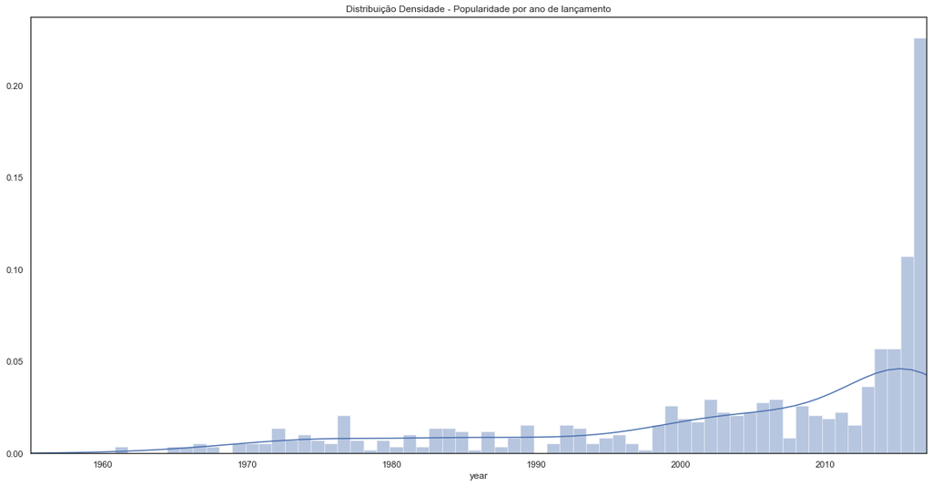

```python
plt.figure( figsize = (20,10))
plt.title('Distribuição Densidade - Popularidade por ano de lançamento')
plt.xlim(1955, 2017)
sns.distplot(SpotifyMost.year, bins = 62)
```

### Aparentemente, nós gostamos mesmo é de novidade.

Alta concentração para músicas do mesmo ano (2017).

E quanto ao padrão nostalgia? Temos aí uns picos e uns vales, quem sabe não vale a pena olhar de forma mais cuidadosa alguns outros padrões?

Vamos primeiro olhar como fica a distribuição das músicas por década.

Para isso, basta fazer o mesmo gráfico, mas agora com menos classes ou 'bins'. Isso vai agrupar as músicas por época.

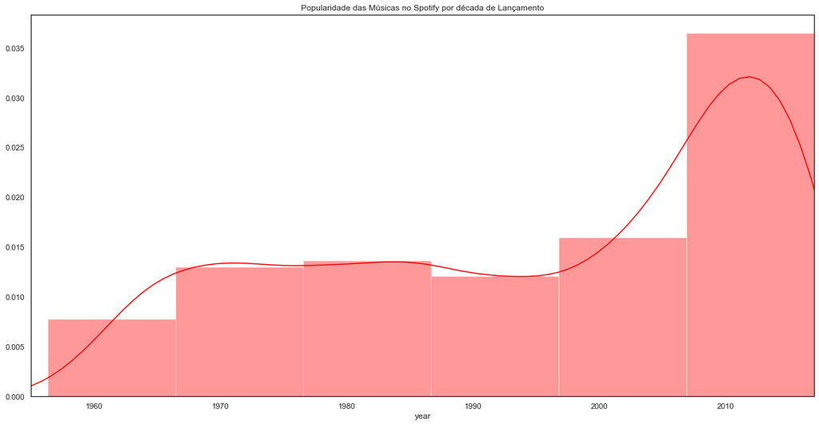

```python
plt.figure( figsize = (20,10))
plt.xlim(1955, 2017)
plt.title("Popularidade das Músicas no Spotify por década de Lançamento")
sns.distplot(SpotifyMost.year, bins = 6, color = 'red')
```

### Aqui vemos que um fenômeno interessante

A músicas populares por década vão caindo quase numa razão constante, até "estacionarem". Devem ser esses os clássicos de cada década.

### 2. Qual a relação entre a popularidade do artista versus a popularidade da música?

Mas também, é um artista popular ter um apanhado de músicas populares, mas outras nem tanto.

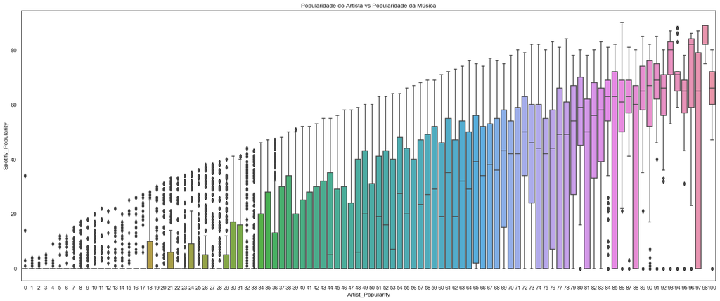

```python
plt.figure( figsize = (25,10))
plt.title('Popularidade do Artista vs Popularidade da Música')
sns.boxplot(x= 'Artist_Popularity', y = 'Spotify_Popularity', data = BoardImpute)
```

### Aqui parece que há 3 "regiões" interessantes.

#### Primeira região: Popularidade do Artista entre 0 e 30:

Essa é a região em que músicas populares são realmente outliers (olha as bolinhas pretas do boxplot, que representa eventos raros). Podem ser desde artistas mais obscuros atualmente, que emplacaram somente uma música e sumiram, enfim. Basta olhar em mais detalhe se necessário.

#### Segunda região: Popularidade do Artista entre 30 e 70:

Aqui parece que temos os artistas famosos que lançam tanto coisas "boas" quanto "ruins".

#### Terceira região: Popularidade entre 70 e 100:

Aqui parece que temos realmente as grandes estrelas, que tudo que lançam vira hit, e o efeito vai ficando cada vez mais forte quando chegamos ao topo.

Podemos ver isso com as medianas altas e em alguns pontos de popularidade box plots bem condensados, com menos amplitude.

Vamos então olhar o grupo dos mais populares em separado.

### Para isso, criarei um grupo, SpotifyMostPopular, para artistas com popularidade acima de 70.

```python
#Criando um objeto para os mais os artistas mais populares:
SpotifyMostPopular = Group[Group.Artist_Popularity >= 70].sort_values('Spotify_Popularity', ascending = False)
#mostrando o cabeçalho:
SpotifyMostPopular.head(25)
```

| Artist | Title | Rank | Weeks on chart | year | Spotify_Popularity | Artist_Popularity |
| --- | --- | --- | --- | --- | --- | --- |
| Mariah Carey | All I Want For Christmas Is You | 28.263158 | 12.000000 | 2014.210526 | 90.0 | 86.0 |
| XXXTENTACION | Jocelyn Flores | 65.642857 | 8.785714 | 2017.000000 | 89.0 | 98.0 |
| Imagine Dragons | Believer | 23.634146 | 23.804878 | 2017.000000 | 88.0 | 94.0 |
| Ariana Grande | Santa Tell Me | 62.600000 | 6.600000 | 2014.400000 | 87.0 | 97.0 |
| Ed Sheeran | Perfect | 30.466667 | 8.533333 | 2017.000000 | 87.0 | 93.0 |
| Imagine Dragons | Thunder | 44.200000 | 16.700000 | 2017.000000 | 86.0 | 94.0 |
| XXXTENTACION | Everybody Dies In Their Nightmares | 73.333333 | 2.666667 | 2017.000000 | 86.0 | 98.0 |
| Post Malone | I Fall Apart | 30.727273 | 7.363636 | 2017.000000 | 86.0 | 96.0 |
| Ed Sheeran | Shape Of You | 9.333333 | 24.422222 | 2017.000000 | 86.0 | 93.0 |
| Dua Lipa | New Rules | 46.222222 | 10.611111 | 2017.000000 | 85.0 | 91.0 |
| Lil Uzi Vert | XO TOUR Llif3 | 21.354839 | 18.225806 | 2017.000000 | 85.0 | 89.0 |
| Wham! | Last Christmas | 45.500000 | 4.500000 | 2017.000000 | 84.0 | 78.0 |
| Khalid | Young Dumb & Broke | 37.550000 | 11.600000 | 2017.000000 | 84.0 | 96.0 |
| Travis Scott | Goosebumps | 61.030303 | 17.393939 | 2016.787879 | 84.0 | 96.0 |
| Kendrick Lamar | Humble. | 19.454545 | 19.272727 | 2017.000000 | 84.0 | 91.0 |
| Ed Sheeran | Happier | 76.500000 | 7.500000 | 2017.000000 | 84.0 | 93.0 |
| Justin Bieber | Mistletoe | 53.000000 | 6.444444 | 2011.222222 | 83.0 | 91.0 |
| NF | Let You Down | 54.375000 | 5.500000 | 2017.000000 | 83.0 | 83.0 |
| Ed Sheeran | Photograph | 27.740741 | 15.814815 | 2015.000000 | 83.0 | 93.0 |
| Toto | Africa | 27.000000 | 11.368421 | 1982.578947 | 83.0 | 76.0 |
| John Legend | All Of Me | 28.740741 | 29.759259 | 2013.833333 | 83.0 | 83.0 |
| Imagine Dragons | Whatever It Takes | 92.000000 | 3.000000 | 2017.000000 | 83.0 | 94.0 |
| Ed Sheeran | Thinking Out Loud | 24.433962 | 29.528302 | 2014.830189 | 83.0 | 93.0 |
| Linkin Park | In The End | 25.305556 | 19.916667 | 2002.194444 | 82.0 | 86.0 |
| 21 Savage | Bank Account | 17.050000 | 12.100000 | 2017.000000 | 82.0 | 89.0 |

```python
#Verificando como é essa série de mais populares.
SpotifyMostPopular.describe()
```

|  | Rank | Weeks on chart | year | Spotify_Popularity | Artist_Popularity |
| --- | --- | --- | --- | --- | --- |
| count | 5880.000000 | 5880.000000 | 5880.000000 | 5880.000000 | 5880.000000 |
| mean | 56.266895 | 8.716551 | 1994.745157 | 39.250510 | 78.313605 |
| std | 23.863147 | 4.470197 | 17.544080 | 25.990237 | 6.663130 |
| min | 7.625000 | 2.000000 | 1956.335260 | 0.000000 | 70.000000 |
| 25% | 35.862500 | 5.500000 | 1979.202381 | 13.000000 | 73.000000 |
| 50% | 56.395833 | 8.138095 | 1999.000000 | 46.000000 | 77.000000 |
| 75% | 76.343750 | 10.888889 | 2010.500000 | 60.000000 | 82.000000 |
| max | 100.000000 | 44.325000 | 2017.000000 | 90.000000 | 100.000000 |

### Legal, altas músicas de 2017, 2016, 2015, 2014.... e de 1982???

Deve ser alguma do Michael Jackson, Madonna, sei lá.

## É uma música da banda Toto. Já ouviu falar?

CLAAAAARO que não.

Well, well! Isso me intrigou por algum tempo, e fui ver as referências a anos 80 que aconteceram em 2017.

Existe uma bastante grande.

Chama-se:

### Stranger Things!

Se não conhece, é uma série do Netflix de suspense/ficção científica ambientada nos anos 80.

Link para a música aqui: https://www.youtube.com/watch?v=giizg8NBoUA

E adivinha: eu escrevendo esse notebook já escutei essa música umas 200x.

#### Nerd is the new sexy!

Lembrando... Trazer esses insights que só encontramos com dados, que é totalmente diferente do que qualquer um chutaria... É esse o trabalho!

#### Prêmio de consolação para Linkin Park!

Pessoal ainda curte um rock, mesmo que tenha um MC no meio para estragar a música.

#### Apenas para critério de visualização, vou criar o Spotify25Most

```python
Spotify25Most = SpotifyMostPopular.head(25)
```

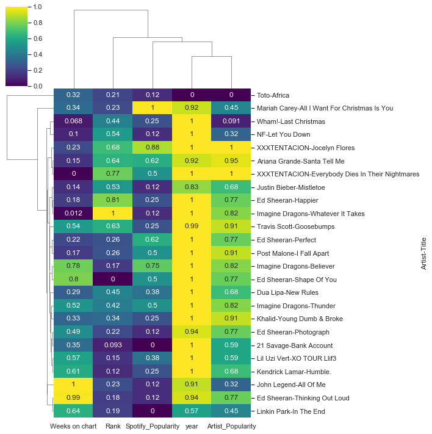

```python
plt.figure( figsize = (25,25))
sns.clustermap(Spotify25Most, metric="correlation", method="single", cmap="viridis", standard_scale=1, annot = True)
```

### 2.1. Olhando um pouco mais a fundo as correlações.

Já que encontramos uma tendência visual para a assertiva: músicos famosos criar hits famosos, vamos tentar trazer um pouco mais de "tutano" para a análise.

Qual o tamanho da correlação que temos entre sucesso do artista versus a música?

E de quebra, qual a correlação entre cada uma das variáveis do modelo?

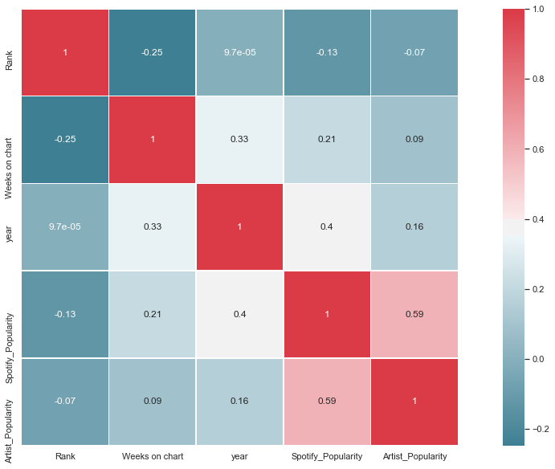

```python
#Aqui sempre é um comando para ajustar o tamanho do gráfico: 20 x 10.
plt.figure( figsize = (20,10))
#criando um objeto que calcula a correlação das variáveis, para guardar e usar como argumento do gráfico.
corr = BoardImpute.corr()
#Aqui é o mapping, para fazer a paleta de cores.
cmap = sns.diverging_palette(220, 10, as_cmap = True)
#comando no seaborn para criar um mapa de calor, usando o objeto corr (criado anteriormente)
sns.heatmap(corr, cmap = cmap,  square = True, linewidth = .5, annot = True)
# o comando annot = True é para apresentar os valores de correlação dentro dos quadrados.
```

Daqui podemos ver que realmente, apenas a popularidade do Artista no Spotify versus a Popularidade da Música no Spotify se relacionam, com um segundo lugar para o ano da música. Aparentemente, para ter um entendimento melhor do Dataset sem o critério "novidade", vamos ter que fazer alguns recortes.

## Encontrando os Hinos - Remoção de outliers.

Agora que realmente sacramentamos a relação entre música nova e popularidade, vamos tentar encontrar aquelas músicas um pouco mais velhinhas de guerra, mas que sobreviveram aos 3 anos de idade e ainda são populares.

Então, vamos remover tudo que foi lançado depois de 2015:

```python
SpotifyAnthems = SpotifyMostPopular[SpotifyMostPopular.year < 2015]
```

```python
SpotifyAnthems.describe()
```

|  | Rank | Weeks on chart | year | Spotify_Popularity | Artist_Popularity |
| --- | --- | --- | --- | --- | --- |
| count | 5215.000000 | 5215.000000 | 5215.000000 | 5215.000000 | 5215.000000 |
| mean | 54.968810 | 8.663074 | 1992.015380 | 36.924832 | 77.489933 |
| std | 23.728936 | 4.369466 | 16.765293 | 25.360691 | 5.984464 |
| min | 7.714286 | 2.000000 | 1956.335260 | 0.000000 | 70.000000 |
| 25% | 34.639319 | 5.555556 | 1977.041667 | 4.000000 | 73.000000 |
| 50% | 54.111111 | 8.076923 | 1994.230769 | 43.000000 | 76.000000 |
| 75% | 74.870833 | 10.833333 | 2008.000000 | 58.000000 | 81.000000 |
| max | 100.000000 | 44.325000 | 2014.947368 | 90.000000 | 100.000000 |

Ainda é bastante música!

```python
SpotifyAnthems.head(50)
```

| Artist | Title | Rank | Weeks on chart | year | Spotify_Popularity | Artist_Popularity |
| --- | --- | --- | --- | --- | --- | --- |
| Mariah Carey | All I Want For Christmas Is You | 28.263158 | 12.000000 | 2014.210526 | 90.0 | 86.0 |
| Ariana Grande | Santa Tell Me | 62.600000 | 6.600000 | 2014.400000 | 87.0 | 97.0 |
| Justin Bieber | Mistletoe | 53.000000 | 6.444444 | 2011.222222 | 83.0 | 91.0 |
| Toto | Africa | 27.000000 | 11.368421 | 1982.578947 | 83.0 | 76.0 |
| John Legend | All Of Me | 28.740741 | 29.759259 | 2013.833333 | 83.0 | 83.0 |
| Ed Sheeran | Thinking Out Loud | 24.433962 | 29.528302 | 2014.830189 | 83.0 | 93.0 |
| Linkin Park | In The End | 25.305556 | 19.916667 | 2002.194444 | 82.0 | 86.0 |
| Sam Smith | Stay With Me | 23.240000 | 27.800000 | 2014.340000 | 82.0 | 90.0 |
| Bobby Helms | Jingle Bell Rock | 55.866667 | 10.266667 | 1971.866667 | 82.0 | 74.0 |
| a-ha | Take On Me | 42.240000 | 14.600000 | 1985.080000 | 82.0 | 73.0 |
| Avicii | Wake Me Up! | 21.938776 | 26.918367 | 2013.530612 | 82.0 | 85.0 |
| AC/DC | Back In Black | 58.571429 | 8.500000 | 1980.857143 | 81.0 | 84.0 |
| Arctic Monkeys | Do I Wanna Know? | 79.368421 | 10.473684 | 2013.894737 | 81.0 | 85.0 |
| Sam Smith | Have Yourself A Merry Little Christmas | 90.000000 | 2.000000 | 2014.000000 | 81.0 | 90.0 |
| AC/DC | Highway To Hell | 62.100000 | 5.600000 | 1979.000000 | 81.0 | 84.0 |
| Michael Jackson | Billie Jean | 26.347826 | 13.869565 | 1984.347826 | 81.0 | 86.0 |
| Foster The People | Pumped Up Kicks | 31.972973 | 20.432432 | 2011.162162 | 81.0 | 77.0 |
| Coldplay | Yellow | 72.111111 | 11.277778 | 2001.000000 | 80.0 | 89.0 |
|  | Fix You | 81.333333 | 5.000000 | 2005.166667 | 80.0 | 89.0 |
| Eagles | Hotel California | 24.500000 | 10.055556 | 1977.000000 | 80.0 | 78.0 |
| Bruno Mars | When I Was Your Man | 24.875000 | 17.593750 | 2012.968750 | 80.0 | 90.0 |
| The Fray | How To Save A Life | 37.870370 | 29.444444 | 2006.388889 | 80.0 | 75.0 |
| Smash Mouth | All Star | 18.814815 | 15.888889 | 1999.000000 | 80.0 | 71.0 |
| Lynyrd Skynyrd | Sweet Home Alabama | 35.062500 | 9.312500 | 1974.000000 | 80.0 | 74.0 |
| Bing Crosby | White Christmas | 41.900000 | 7.500000 | 1960.800000 | 80.0 | 82.0 |
| Queen | Bohemian Rhapsody | 29.342105 | 21.157895 | 1982.736842 | 80.0 | 97.0 |
| Radiohead | Creep | 56.000000 | 10.777778 | 1993.000000 | 80.0 | 80.0 |
| Eurythmics | Sweet Dreams (Are Made Of This) | 30.041667 | 13.375000 | 1983.000000 | 80.0 | 71.0 |
| Linkin Park | Numb | 29.133333 | 17.166667 | 2004.200000 | 80.0 | 86.0 |
| Maroon 5 | She Will Be Loved | 19.270270 | 21.351351 | 2004.432432 | 80.0 | 90.0 |
| Red Hot Chili Peppers | Under The Bridge | 20.291667 | 13.625000 | 1992.000000 | 80.0 | 85.0 |
| TLC | No Scrubs | 13.538462 | 14.192308 | 1999.000000 | 79.0 | 73.0 |
| Tears For Fears | Everybody Wants To Rule The World | 34.954545 | 12.818182 | 1985.000000 | 79.0 | 72.0 |
| Gorillaz | Feel Good Inc | 32.904762 | 23.452381 | 2005.309524 | 79.0 | 80.0 |
| Whitney Houston | I Wanna Dance With Somebody (Who Loves Me) | 22.888889 | 10.888889 | 1989.777778 | 79.0 | 78.0 |
| Spice Girls | Wannabe | 11.047619 | 13.142857 | 1997.000000 | 79.0 | 73.0 |
| Red Hot Chili Peppers | Californication | 77.941176 | 10.529412 | 2000.000000 | 79.0 | 85.0 |
| R.E.M. | Losing My Religion | 34.000000 | 11.050000 | 1991.000000 | 79.0 | 75.0 |
| Christina Perri | A Thousand Years | 48.875000 | 13.416667 | 2011.666667 | 78.0 | 75.0 |
| Alicia Keys | No One | 12.371429 | 20.114286 | 2007.628571 | 78.0 | 79.0 |
| The Verve | Bitter Sweet Symphony | 47.315789 | 11.263158 | 1998.000000 | 78.0 | 70.0 |
| Eminem | Without Me | 16.333333 | 11.000000 | 2002.000000 | 78.0 | 95.0 |
| Guns N' Roses | November Rain | 14.222222 | 11.000000 | 1992.000000 | 78.0 | 82.0 |
| Electric Light Orchestra | Mr. Blue Sky | 65.181818 | 6.636364 | 1978.000000 | 78.0 | 74.0 |
| Papa Roach | Last Resort | 64.777778 | 11.055556 | 2000.000000 | 78.0 | 76.0 |
| Red Hot Chili Peppers | Snow ((Hey Oh)) | 45.388889 | 11.444444 | 2006.777778 | 78.0 | 85.0 |
| System Of A Down | Chop Suey | 86.578947 | 10.473684 | 2002.000000 | 78.0 | 80.0 |
| Blink-182 | All The Small Things | 32.952381 | 11.714286 | 1999.809524 | 78.0 | 80.0 |
| Leona Lewis | Bleeding Love | 19.555556 | 20.583333 | 2008.000000 | 78.0 | 75.0 |
| Creedence Clearwater Revival | Fortunate Son | 30.250000 | 4.250000 | 1969.000000 | 78.0 | 79.0 |

### Aqui, mesmo que você não seja um super conhecedor de música, você encontrará muita coisa familiar!

Vamos ver como fica a relação Popularidade do Artista versus Música?

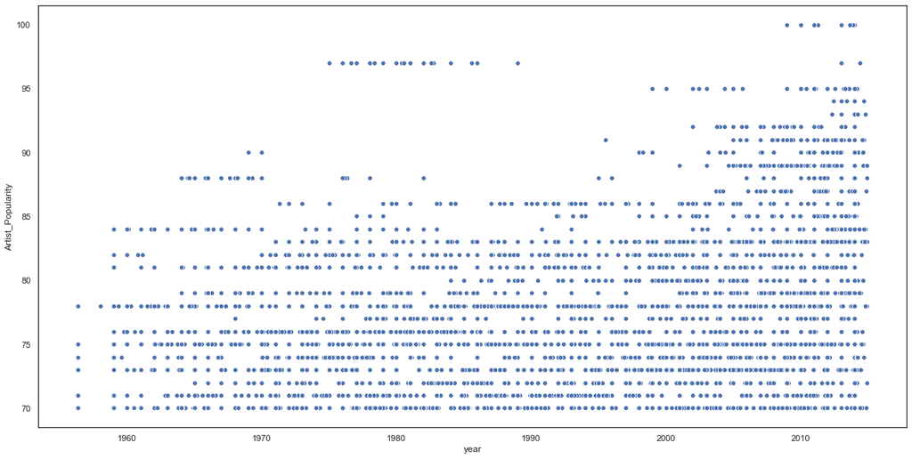

```python
plt.figure( figsize = (20,10))
sns.scatterplot(x = 'year', y = 'Artist_Popularity', data = SpotifyAnthems)
```

Aparentemente o fator novidade não existe tão fortemente; existe, talvez o fator "velhice", para o caso das músicas dos anos 50 e 60.

### Agora, verificando o heatmap de correlação, usando o mesmo código, trocando apenas a paleta de cores e o qual o objeto que vamos correlacionar, agora SpotifyAnthems.

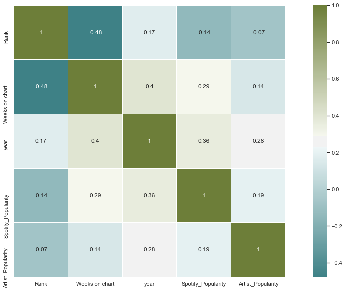

```python
#Aqui sempre é um comando para ajustar o tamanho do gráfico: 20 x 10.
plt.figure( figsize = (20,10))
#criando um objeto que calcula a correlação das variáveis, para guardar e usar como argumento do gráfico.
corr = SpotifyAnthems.corr()
#Aqui é o mapping, para fazer a paleta de cores.
cmap = sns.diverging_palette(200, 100, as_cmap = True)
#comando no seaborn para criar um mapa de calor, usando o objeto corr (criado anteriormente)
sns.heatmap(corr, cmap = cmap,  square = True, linewidth = .5, annot = True)
# o comando annot = True é para apresentar os valores de correlação dentro dos quadrados.
```

## Agora, vamos fazer o contrário: Será que a Billboard está acertando quem é popular mesmo?

Afinal de contas, pelo que temos visto aqui, o que a Billboard disse no momento pouco reflete a popularidade de hoje.

Vamos agora olhar as músicas mais populares e comparar com o que a Billboard tem a dizer sobre elas!

```python
BillboardSpotify = SpotifyMostPopular[SpotifyMostPopular.year >= 2015]
```

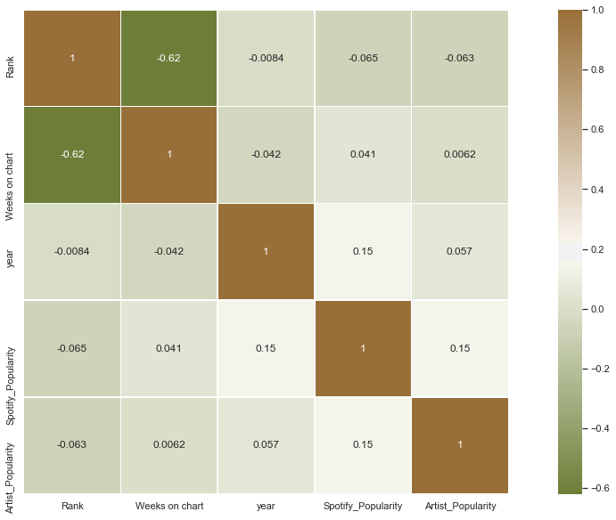

```python
#Aqui sempre é um comando para ajustar o tamanho do gráfico: 20 x 10.
plt.figure( figsize = (20,10))
#criando um objeto que calcula a correlação das variáveis, para guardar e usar como argumento do gráfico.
corr = BillboardSpotify.corr()
#Aqui é o mapping, para fazer a paleta de cores.
cmap = sns.diverging_palette(100, 50, as_cmap = True)
#comando no seaborn para criar um mapa de calor, usando o objeto corr (criado anteriormente)
sns.heatmap(corr, cmap = cmap,  square = True, linewidth = .5, annot = True)
# o comando annot = True é para apresentar os valores de correlação dentro dos quadrados.
```

### É... Parece que a Billboard parou de manjar das coisas em algum ponto da história.

```python
BillboardSpotify.describe()
```

|  | Rank | Weeks on chart | year | Spotify_Popularity | Artist_Popularity |
| --- | --- | --- | --- | --- | --- |
| count | 665.000000 | 665.000000 | 665.000000 | 665.000000 | 665.000000 |
| mean | 66.446619 | 9.135922 | 2016.152353 | 57.488722 | 84.772932 |
| std | 22.437622 | 5.177463 | 0.767628 | 23.553073 | 8.046805 |
| min | 7.625000 | 2.000000 | 2015.000000 | 0.000000 | 70.000000 |
| 25% | 52.850000 | 5.000000 | 2015.517241 | 57.000000 | 78.000000 |
| 50% | 71.000000 | 8.500000 | 2016.000000 | 64.000000 | 85.000000 |
| 75% | 83.666667 | 11.157895 | 2017.000000 | 72.000000 | 91.000000 |
| max | 100.000000 | 27.000000 | 2017.000000 | 89.000000 | 100.000000 |

### Finalmente, a lista das músicas novas mais populares.

E não conhecer grande parte desses artistas me trouxe a realidade que estou ficando velho.

```python
BillboardSpotify.head(50)
```

| Artist | Title | Rank | Weeks on chart | year | Spotify_Popularity | Artist_Popularity |
| --- | --- | --- | --- | --- | --- | --- |
| XXXTENTACION | Jocelyn Flores | 65.642857 | 8.785714 | 2017.000000 | 89.0 | 98.0 |
| Imagine Dragons | Believer | 23.634146 | 23.804878 | 2017.000000 | 88.0 | 94.0 |
| Ed Sheeran | Perfect | 30.466667 | 8.533333 | 2017.000000 | 87.0 | 93.0 |
| Imagine Dragons | Thunder | 44.200000 | 16.700000 | 2017.000000 | 86.0 | 94.0 |
| XXXTENTACION | Everybody Dies In Their Nightmares | 73.333333 | 2.666667 | 2017.000000 | 86.0 | 98.0 |
| Post Malone | I Fall Apart | 30.727273 | 7.363636 | 2017.000000 | 86.0 | 96.0 |
| Ed Sheeran | Shape Of You | 9.333333 | 24.422222 | 2017.000000 | 86.0 | 93.0 |
| Dua Lipa | New Rules | 46.222222 | 10.611111 | 2017.000000 | 85.0 | 91.0 |
| Lil Uzi Vert | XO TOUR Llif3 | 21.354839 | 18.225806 | 2017.000000 | 85.0 | 89.0 |
| Wham! | Last Christmas | 45.500000 | 4.500000 | 2017.000000 | 84.0 | 78.0 |
| Khalid | Young Dumb & Broke | 37.550000 | 11.600000 | 2017.000000 | 84.0 | 96.0 |
| Travis Scott | Goosebumps | 61.030303 | 17.393939 | 2016.787879 | 84.0 | 96.0 |
| Kendrick Lamar | Humble. | 19.454545 | 19.272727 | 2017.000000 | 84.0 | 91.0 |
| Ed Sheeran | Happier | 76.500000 | 7.500000 | 2017.000000 | 84.0 | 93.0 |
| NF | Let You Down | 54.375000 | 5.500000 | 2017.000000 | 83.0 | 83.0 |
| Ed Sheeran | Photograph | 27.740741 | 15.814815 | 2015.000000 | 83.0 | 93.0 |
| Imagine Dragons | Whatever It Takes | 92.000000 | 3.000000 | 2017.000000 | 83.0 | 94.0 |
| 21 Savage | Bank Account | 17.050000 | 12.100000 | 2017.000000 | 82.0 | 89.0 |
| Khalid | Location | 34.600000 | 21.925000 | 2017.000000 | 82.0 | 96.0 |
| Alan Walker | Faded | 92.428571 | 5.000000 | 2016.000000 | 82.0 | 86.0 |
| XXXTENTACION | Look At Me! | 57.526316 | 10.894737 | 2017.000000 | 82.0 | 98.0 |
| twenty one pilots | Stressed Out | 29.145833 | 26.812500 | 2015.770833 | 82.0 | 89.0 |
| Justin Bieber | Love Yourself | 13.710526 | 21.210526 | 2015.894737 | 82.0 | 91.0 |
| Ariana Grande | One Last Time | 32.789474 | 10.526316 | 2015.000000 | 81.0 | 97.0 |
| twenty one pilots | Ride | 29.916667 | 20.222222 | 2016.000000 | 81.0 | 89.0 |
| Demi Lovato | Sorry Not Sorry | 15.200000 | 12.100000 | 2017.000000 | 81.0 | 87.0 |
| Ariana Grande | Into You | 33.090909 | 12.681818 | 2016.000000 | 81.0 | 97.0 |
| Ed Sheeran | Galway Girl | 78.400000 | 5.200000 | 2017.000000 | 81.0 | 93.0 |
| Portugal. The Man | Feel It Still | 26.565217 | 13.434783 | 2017.000000 | 81.0 | 76.0 |
| Drake | Passionfruit | 36.666667 | 11.000000 | 2017.000000 | 80.0 | 100.0 |
| XXXTENTACION | Revenge | 86.500000 | 7.000000 | 2017.000000 | 80.0 | 98.0 |
| Kendrick Lamar | DNA. | 37.000000 | 10.789474 | 2017.000000 | 80.0 | 91.0 |
| XXXTENTACION | Carry On | 95.000000 | 5.000000 | 2017.000000 | 80.0 | 98.0 |
| Ed Sheeran | Castle On The Hill | 41.000000 | 17.193548 | 2017.000000 | 80.0 | 93.0 |
| J. Cole | No Role Modelz | 57.000000 | 12.956522 | 2015.260870 | 80.0 | 88.0 |
| twenty one pilots | Heathens | 14.638889 | 20.750000 | 2016.361111 | 80.0 | 89.0 |
| The Weeknd | The Hills | 14.318182 | 24.568182 | 2015.386364 | 80.0 | 91.0 |
| Lady Gaga | Million Reasons | 53.722222 | 11.277778 | 2016.777778 | 80.0 | 92.0 |
| Future | Mask Off | 19.750000 | 15.928571 | 2017.000000 | 80.0 | 91.0 |
| Post Malone | Go Flex | 91.000000 | 6.181818 | 2016.909091 | 80.0 | 96.0 |
| Childish Gambino | Redbone | 46.025000 | 22.525000 | 2016.950000 | 80.0 | 82.0 |
| Justin Bieber | Sorry | 16.897436 | 21.538462 | 2015.820513 | 79.0 | 91.0 |
| Ed Sheeran | Supermarket Flowers | 75.000000 | 16.000000 | 2017.000000 | 79.0 | 93.0 |
| Ariana Grande | Dangerous Woman | 18.578947 | 11.368421 | 2016.000000 | 79.0 | 97.0 |
| Taylor Swift | Look What You Made Me Do | 27.133333 | 9.933333 | 2017.000000 | 78.0 | 89.0 |
| XXXTENTACION | Depression & Obsession | 91.000000 | 5.000000 | 2017.000000 | 78.0 | 98.0 |
| Halsey | Bad At Love | 34.461538 | 8.153846 | 2017.000000 | 78.0 | 91.0 |
| Sam Hunt | Body Like A Back Road | 19.789474 | 21.000000 | 2017.000000 | 78.0 | 74.0 |
| Bryson Tiller | Exchange | 46.125000 | 17.531250 | 2015.781250 | 78.0 | 81.0 |
| Kane Brown | Heaven | 72.000000 | 8.000000 | 2017.000000 | 78.0 | 79.0 |

## Conclusão

O objetivo desse notebook era trazer algumas possibilidades para investigarmos uma base de dados, com algum assunto que as pessoas realmente se interessem!

Quem é curioso e quer desenvolver mais, pode usar o código simples que utilizei aqui e sair brincando com os seus próprios dados.

Se você passou aqui apenas de curioso, pode ao menos montar uma playlist pra uma festa!

Um abraço!